# Canada’s Population Change in Shiny

Kyle Rozic

4/22/2021

# Introduction

My goal for this project was to work more with maps to create choropleth visualizations of Canadian population. All data was obtained from publicly available datasets at Stats Canada.

My final application allows the user to select years from a drop down to visualize the population change per 10k citizens on a leaflet choropleth map. The only library that may not be recognized by classmates is `sf` which is used to handle shape data (for maps).

```r
library(shiny)
library(dplyr)
library(data.table)
library(sf)
library(RColorBrewer)
library(leaflet)
library(tidyr)
library(ggplot2)
```

# The Data

After spending a lot of time finding and preparing the data to work with this project, I made 2 final datasets that are used for this final project: A tall dataset containing population values for each census district factorized by year, and the shape data to draw the cartographic boundaries.

```r
popTot <- read.csv('./data/popTot.csv',
                   na.strings = '')
shp <- st_read('./data/division_shapes_digital/lcd_000a16a_e.shp',
               stringsAsFactors = F)
```

```r
head(popTot)
```

```
##                                   GEO              CITY         PROVINCE CDUID
## 1               Abitibi-Ouest, Quebec     Abitibi-Ouest           Quebec  2487
## 2                     Abitibi, Quebec           Abitibi           Quebec  2488
## 3                       Acton, Quebec             Acton           Quebec  2448
## 4 Alberni-Clayoquot, British Columbia Alberni-Clayoquot British Columbia  5923
## 5               Albert, New Brunswick            Albert    New Brunswick  1306
## 6                     Algoma, Ontario            Algoma          Ontario  3557
##   YEAR POPULATION
## 1 2001      22324
## 2 2001      25031
## 3 2001      15454
## 4 2001      31598
## 5 2001      27516
## 6 2001     123765
```

```r
head(shp)
```

```
## Simple feature collection with 6 features and 5 fields
## geometry type:  MULTIPOLYGON
## dimension:      XY
## bbox:           xmin: 8248398 ymin: 1215677 xmax: 8437688 ymax: 1681815
## projected CRS:  PCS_Lambert_Conformal_Conic
##   CDUID    CDNAME CDTYPE PRUID                                       PRNAME
## 1  1101     Kings    CTY    11 Prince Edward Island / Île-du-Prince-Édouard
## 2  1102    Queens    CTY    11 Prince Edward Island / Île-du-Prince-Édouard
## 3  1103    Prince    CTY    11 Prince Edward Island / Île-du-Prince-Édouard
## 4  1201 Shelburne    CTY    12                Nova Scotia / Nouvelle-Écosse
## 5  1202  Yarmouth    CTY    12                Nova Scotia / Nouvelle-Écosse
## 6  1208     Hants    CTY    12                Nova Scotia / Nouvelle-Écosse
##                         geometry
## 1 MULTIPOLYGON (((8427170 163...
## 2 MULTIPOLYGON (((8382758 163...
## 3 MULTIPOLYGON (((8294355 163...
## 4 MULTIPOLYGON (((8297919 133...
## 5 MULTIPOLYGON (((8297919 133...
## 6 MULTIPOLYGON (((8389627 150...
```

# Visualizing with `ggplot2`

In R, districts are quickly visualized with `ggplot2`. First I spread the data so it’s more easily handled, then I merged it with the shape data:

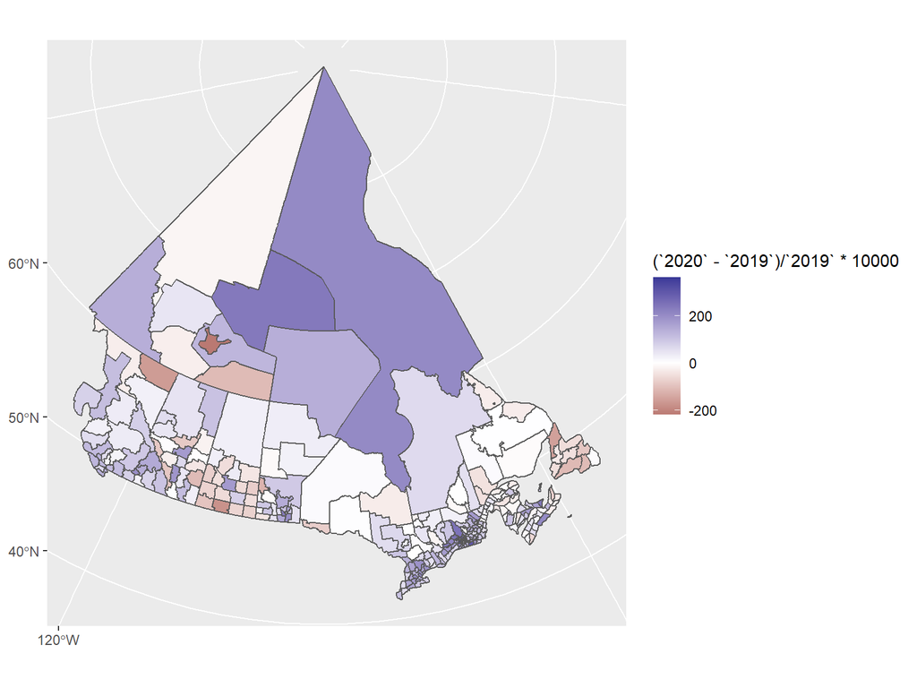

```r
popTot <- spread(popTot, YEAR, POPULATION) %>%
        select(-GEO)
popMap <- st_as_sf(merge(popTot, shp))

ggplot() +
        geom_sf(data = popMap, aes(fill = (`2020`-`2019`)/`2019`*10000)) +
        scale_fill_gradient2()
```

The index.html file was too large when containing the leaflet app, so I used ggplot instead.

This is an example of the type of plot I will be making in leaflet, with the same calculation. In this example, the population change is visualized between 2019 and 2020.

# Notes on shiny implementation

I thought the shiny application would be a pretty straight forward implementation of the above `ggplot2` code, however the reactive environment introduced some troubles which were difficult to troubleshoot in the reactive environment.

For example, reactive elements cannot be transformed on the right side of the assignment operation and reassigned to itself on the left side, as this will create an infinite loop of reactivity. (ex. `val <- val + 1`)

Also, while subsetting reactive data frames does behave normally most of the time, I did notice it break once or twice. Sometimes calling a single column or variable from a data frame returned a list containing a vector, rather than just the vector itself. This caused problems with calculations that were working before.

Anyway, here is the code:

```r
library(shiny)
library(shinydashboard)
library(leaflet)

shinyUI(dashboardPage(
    skin = 'blue',
    dashboardHeader(title = 'Canada Population Change'),
    dashboardSidebar(
        h1('Choose Year'),
        selectInput('date1', 'Start Date:', seq(2001, 2020)),
        selectInput('date2', 'End Date:', seq(2001, 2020), selected = 2002),
        h1('Choose Table Type'),
        selectInput('tableType', 'Contents:', c('All Years', 'Change')),
        column(12,
               style = 'margin-left: 70px',
               submitButton('Apply'))
    ),
    dashboardBody(
        fluidRow(box(width = 12, leafletOutput(outputId = 'map', height = 500))),
        fluidRow(box(width = 12, dataTableOutput(outputId = 'summary_table')))
    )
))
```

```r
library(shiny)
library(dplyr)
library(data.table)
library(sf)
library(RColorBrewer)
library(leaflet)
library(tidyr)

popTot <- read.csv('./data/popTot.csv',
                   na.strings = '')
popTot <- spread(popTot, YEAR, POPULATION) %>%
        select(-GEO)
shp <- st_read('./data/division_shapes_digital/lcd_000a16a_e.shp',
               stringsAsFactors = F)

shinyServer(function(input, output) {
        date1 <- reactive({grep(input$date1, names(popTot))})
        date2 <- reactive({grep(input$date2, names(popTot))})
        inputData <- reactive({
                popTot %>%
                        mutate(CHANGE_PER_10k = round((popTot[date2()]-popTot[date1()])/popTot[date1()]*10000)) %>%
                        select(CITY, PROVINCE, CHANGE_PER_10k, CDUID)
        })
        popMap <- reactive({st_as_sf(merge(inputData(), shp)) %>%
                st_transform('+init=epsg:4326')})

        minVal <- reactive({min(popMap()$CHANGE_PER_10k)})
        maxVal <- reactive({max(popMap()$CHANGE_PER_10k)})
        domain <- reactive({c(minVal(), maxVal())})
        colorPal <- reactive({c(colorRampPalette(colors = brewer.pal(11, 'RdBu')[c(1:4, 6)],
                                       space = 'Lab')(abs(minVal()/10)),
                      colorRampPalette(colors = brewer.pal(11, 'RdBu')[c(6, 8:11)],
                                       space = 'Lab')(maxVal()/10)[-1])})
        colorPalInput <- reactive({colorNumeric(colorPal(), domain())})

        labels = reactive({sprintf('<strong>%s, %s</strong><br/>%g net migration/10k',
                         popMap()$CITY,
                         popMap()$PROVINCE,
                         popMap()$CHANGE_PER_10k[[1]]) %>%
                lapply(htmltools::HTML)})

        output$map <- renderLeaflet({
                popMap() %>%
                leaflet() %>%
                addProviderTiles('Stamen.TonerLite') %>%
                setView(lng = -95, lat = 60, zoom = 3) %>%
                addPolygons(color = '#444444',
                            weight = 1,
                            smoothFactor = 0.5,
                            opacity = 1,
                            fillOpacity = 0.7,
                            fillColor = ~colorPalInput()(popMap()$CHANGE_PER_10k[[1]]),
                            highlightOptions = highlightOptions(color = 'white',
                                                                weight = 2,
                                                                bringToFront = T),
                            label = labels(),
                            labelOptions = labelOptions(
                                    style = list('font-weight' = 'normal',
                                                 padding = '3px 8px'),
                                    textsize = '15px',
                                    direction = 'auto')) %>%
                addLegend(pal = colorPalInput(),
                          values = domain(),
                          opacity = 0.7,
                          title = 'Net Migration Per 10k',
                          position = 'bottomright')
        })
        tableType <- reactive({if(input$tableType == 'All Years'){popTot} else{inputData()}})
        output$summary_table <- renderDataTable(tableType(),
                                                options = list(pageLength = 25,
                                                               width = '100%',
                                                               scrollx = T))
})
```

I used `shinydashboard` to make a slightly different looking web UI.

[shiny link](https://krozic.shinyapps.io/shiny_app/)

To use the app:

1. Choose the dates you would like to observe the change for.
2. Choose the type of table you would like to view.
3. Click ‘Apply’.

**Have a great day stranger!**